# TestingThings

Laura Groot

2024-03-09

In this RMarkdown I document my workflow. I imagine this as a series of questions, where one naturally leads to the next.

```r
library(VGAM)
library(AmoRosoDistrib)
library(devtools)

# Load my functions
source_url("https://raw.githubusercontent.com/L-Groot/AmorosoDensityEstimation/main/functions.R")
```

### (1) Amoroso = Stacy

Amoroso = Stacy when mu = 0.

The Stacy distribution (or 3-parameter generalized gamma) is just the Amoroso without the location parameter mu. So the difference between them is that the Amoroso has an extra location parameter that shifts the distribution along the x axis.

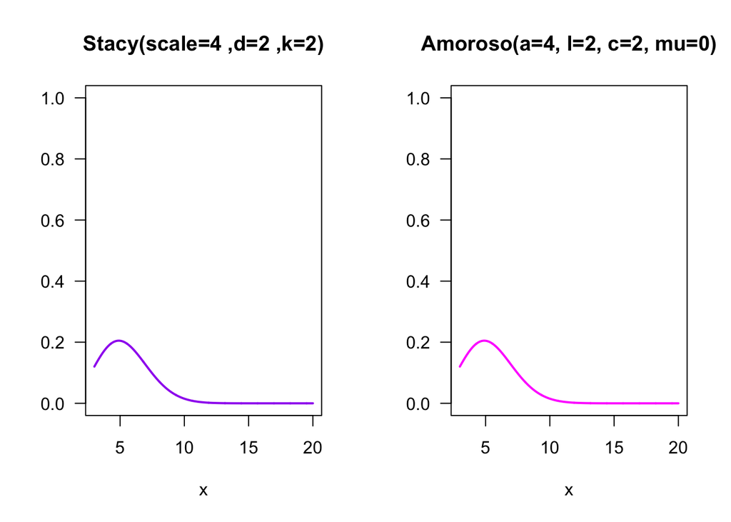

```r
# PDF for 3-par GG
dggamma <- function(t, theta, kappa, delta, log = FALSE){
  val <- log(delta) - kappa*log(theta) - lgamma(kappa/delta) + (kappa - 1)*log(t) -
  (t/theta)^delta
  if(log) return(val) else return(exp(val))
}

# Quantile Function for 3-par GG
qggamma <- function(p, theta, kappa, delta){
  out <- qgamma(p, shape = kappa/delta, scale = theta^delta)^(1/delta)
  return(out)
}

# Split plotting window in 2
par(mfrow = c(1,2))

# Set x range
x <- seq(3, 20, by = 0.01)

# Set parameters for 3GG
scale <- 4
shape1 <- 2
shape2 <- 2

# Stacy
plot(x, dgengamma.stacy(x, scale = scale, d = shape1, k = shape2), type = "l",
     col = "purple", ylim = 0:1,
     main = paste0("Stacy(scale=",scale," ,d=",shape1," ,k=",shape2,")"),
     las = 1, ylab = "", lwd = 2)

# Amoroso with same parameters and mu = 0
plot(x, dAmoroso(x, a = scale, l = shape2, c = shape1, mu = 0), type = "l",
     col = "magenta", ylim = 0:1,
     main = paste0("Amoroso(a=",scale,", l=",shape2,", c=",shape1, ", mu=0)"),
     las = 1, ylab = "", lwd = 2)
```

```r
# --> this also works with dgg4() instead of dAmoroso()!
```

### (2) Amoroso = Gamma

Amoroso is Gamma when c = 1 and mu = 0.

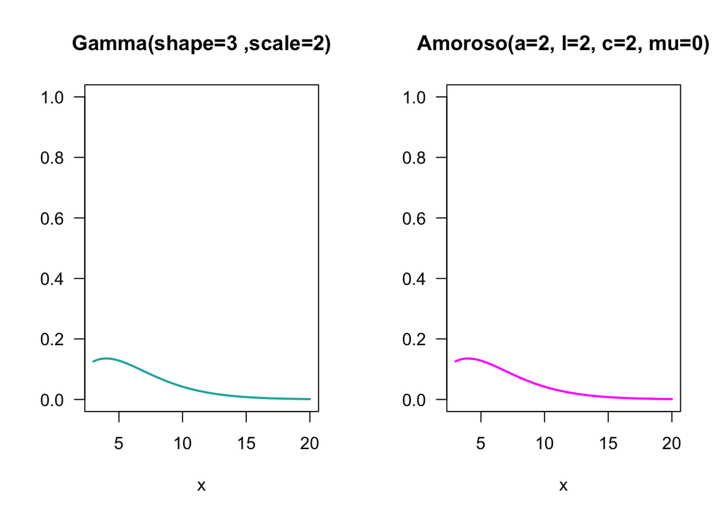

```r
# Split plotting window in 2
par(mfrow = c(1,2))

# Set parameters
scale = 2
shape = 3

# Define x
x <- seq(3, 20, by = 0.01)

# Gamma
plot(x, dgamma(x, shape = shape, scale = scale), type = "l",
     col = "lightseagreen", ylim = 0:1,
     main = paste0("Gamma(shape=",shape," ,scale=",scale,")"),
     las = 1, ylab = "", lwd = 2)

# Amoroso
plot(x, dAmoroso(x, a = scale, l = shape, c = 1, mu = 0), type = "l",
     col = "magenta", ylim = 0:1,
     main = paste0("Amoroso(a=",scale,", l=",shape2,", c=",shape1, ", mu=0)"),
     las = 1, ylab = "", lwd = 2)
```

### (3) Amoroso = Weibull

Amoroso is Weibull when l = c = 1.

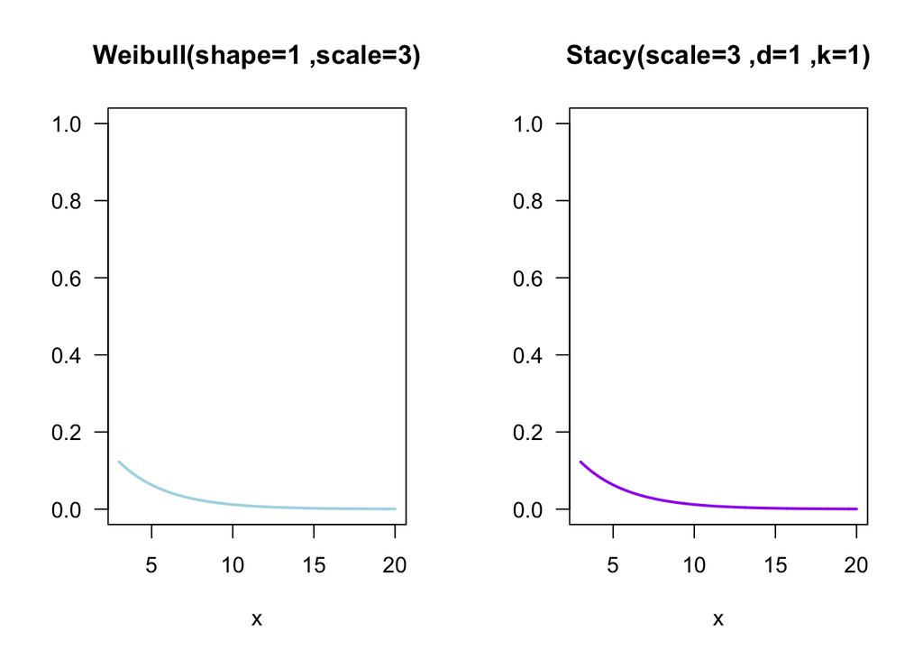

```r
# Split plotting window in 2
par(mfrow = c(1,2))

# Set parameters
scale = 3
shape = 1

# Define x
x <- seq(3, 20, by = 0.01)

# Weibull
plot(x, dweibull(x, shape = shape, scale = scale), type = "l",
     col = "lightblue", ylim = 0:1,
     main = paste0("Weibull(shape=",shape," ,scale=",scale,")"),
     las = 1, ylab = "", lwd = 2)

# Stacy
plot(x, dgengamma.stacy(x, scale = scale, d = shape, k = shape), type = "l",
     col = "purple", ylim = 0:1,
     main = paste0("Stacy(scale=",scale," ,d=",shape," ,k=",shape,")"),
     las = 1, ylab = "", lwd = 2)
```

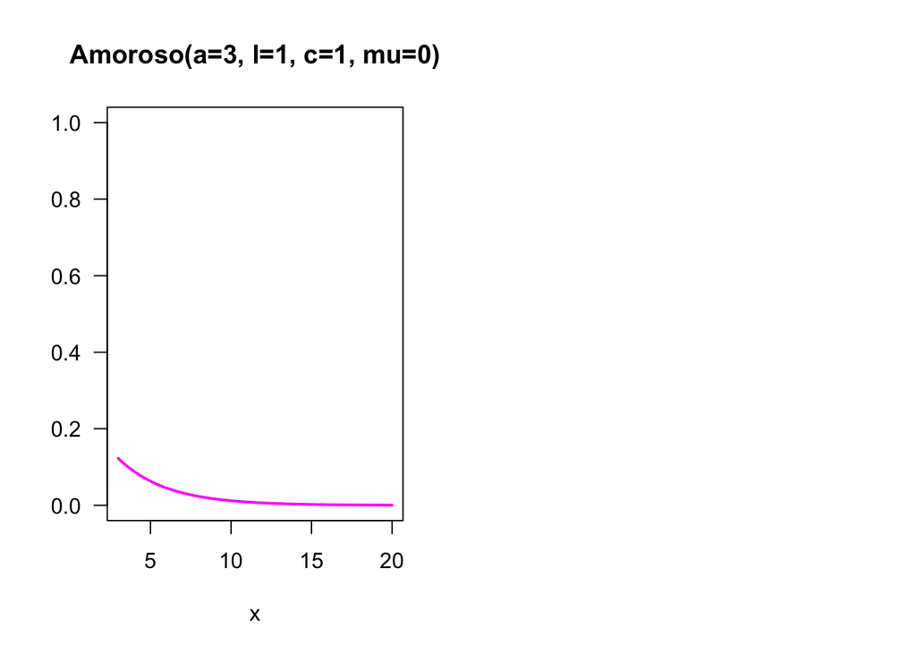

```r
# Amoroso
plot(x, dAmoroso(x, a = scale, l = shape, c = shape, mu = 0), type = "l",
     col = "magenta", ylim = 0:1,
     main = paste0("Amoroso(a=",scale,", l=",shape,", c=",shape, ", mu=0)"),
     las = 1, ylab = "", lwd = 2)
```

### Question 2: Does the MLE method always result in the lowest BIC?

Theoretically MLE promises that it finds the set of parameters that maximises the likelihood. Since all Amoroso fits have the same number of parameters (4), they all get the same punishment term in the BIC formula. Therefore, if we compare Amoroso fits to each other, the model with the lowest BIC must have the highest likelihood. Theoretically, the MLE method should always results in the lowest BIC. Here, I investigate if this is indeed the case; Does the MLE Amoroso fit indeed always have a lower BIC than all the MDE methods?

```r
# Check out existing datasets
#data()

# Estimate Amoroso with MLE and MDE methods on different variables
# estimateAmoroso_MLE_MDE(airquality$Temp) #lowest BIC: MLE+
# estimateAmoroso_MLE_MDE(airquality$Wind) #lowest BIC: MLE-
# estimateAmoroso_MLE_MDE(faithful$eruptions) #lowest BIC: MLE+
# # --> bad fit of Amoroso because data is bimodal
# estimateAmoroso_MLE_MDE(faithful$waiting) #lowest BIC: MLE+
# estimateAmoroso_MLE_MDE(diamonds$carat) #lowest BIC: MLE-
# estimateAmoroso_MLE_MDE(diamonds$price) #lowest BIC: MLE+

# --> fitting Amoroso to diamonds takes much longer because it has many observations

length(Nile) # n = 100
```

```
## [1] 100
```

```r
nrow(diamonds) # n = 53940
```

```
## [1] 53940
```

```r
nrow(airquality) # n = 153
```

```
## [1] 153
```